# AGBRESA Spatial Cognition 1

## 3.7 Mixed Model Time x Group Interaction

```r
# Add baseline as cov
bdc <- "BDC-3"
df_tmp <-  func_bdc_cov(df_navis_2d)

# Select dep vars
dvList <- c("rt_z","acc_z","total_distance_z","total_revisits_z")

# Define model
model_mm <- paste0(" + sex"," + age", " + time.f",  " * group_3", " * cond.f", " + (1|id)" )

# Run mixed models
tbl_mm_fac_aov <- sapply(func_mm_fac_with_bdc_adj_help(dvList), anova, simplify = FALSE, USE.NAMES = TRUE)

# ANOVA table
tbl_mm_fac_aov_df <- func_tbl_aov(dvList)

# Helper functions for parameter definition in mixed model tables, takes 'dvList'
Parameter_func <- function(dvList){
  rep(c(
  "Baseline",
  "Sex",
  "Age",
  "Time",
  "Group",
  "Task Condition",
  "Time x Group",
  "Time x Task Condition",
  "Group x Task Condition",
  "Time x Group x Task Condition"),
                 length(dvList))
}

# Add variables
Parameter <- Parameter_func(dvList)
blanks <- rep("", length(Parameter) / length(dvList) - 1)
Variable <- c("Speed", blanks,"Accuracy", blanks, "Distance", blanks, "Total Revisits",
              blanks)
tbl_mm_fac_aov_df_navis_2d <- cbind(Variable, Parameter, tbl_mm_fac_aov_df[c(4:7)])
```

#### 3.7.0.1 Table 10. Mixed Model Summary for Navigation Search Task 2D.

| Variable | Parameter | df1 | df2 | F | P |
| --- | --- | --- | --- | --- | --- |
| Speed | Baseline | 1 | 326.05 | 1.17 | 0.281 |
|  | Sex | 1 | 17.39 | 2.74 | 0.116 |
|  | Age | 1 | 26.01 | 13.21 | 0.001 |
|  | Time | 3 | 336.24 | 4.7 | 0.003 |
|  | Group | 2 | 17.21 | 0.22 | 0.804 |
|  | Task Condition | 1 | 336.24 | 6.14 | 0.014 |
|  | Time x Group | 6 | 336.24 | 1.34 | 0.238 |
|  | Time x Task Condition | 3 | 336.24 | 2.77 | 0.041 |
|  | Group x Task Condition | 2 | 336.24 | 1.78 | 0.171 |
|  | Time x Group x Task Condition | 6 | 336.24 | 2.02 | 0.063 |

[output cut: 30 more lines]

##Contrasts for Comparing Groups at Each Time Point

```r
# Contrasts
# Define model for contrasts
model_emmeans <- ~ time.f * group_3 * cond.f

# Define contrasts
contrast_type <- "pairwise"
factors <- c("cond.f", "time.f")

# Run contrasts
tbl_contr_emm_fac_df <- func_tbl_contr_emm_fac_with_bdc_adj(dvList)

# Create vars to make nice table
tmp_n_dvs <- length(levels(tbl_contr_emm_fac_df$Contrast)) *
  length(levels(tbl_contr_emm_fac_df$time.f)) *
  length(levels(tbl_contr_emm_fac_df$cond.f)) -1
tmp_n_cond <- length(levels(tbl_contr_emm_fac_df$Contrast)) *
  length(levels(tbl_contr_emm_fac_df$time.f)) - 1
tmp_n_time <- length(levels(tbl_contr_emm_fac_df$Contrast)) - 1

Variable <- c("Speed", blanks,"Accuracy", blanks, "Distance", blanks, "Total Revisits")

tbl_contr_emm_fac_df$Variable <- c("Speed", rep("", tmp_n_dvs),
                                   "Accuracy", rep("", tmp_n_dvs),
                                   "Distance", rep("", tmp_n_dvs),
                                   "Total Revisits", rep("", tmp_n_dvs))

tbl_contr_emm_fac_df$Condition <- rep ( c("Day", rep("", tmp_n_cond),
                                          "Night",rep("", tmp_n_cond)),
                                        length(dvList) )

tbl_contr_emm_fac_df$Time <- rep ( c("HDT2", rep("", tmp_n_time),
                                     "HDT30", rep("", tmp_n_time),
                                     "HDT59", rep("", tmp_n_time),
                                     "R+12", rep("", tmp_n_time)),
                                   length(dvList) )

#table_contrasts_emm_fac_by_time_df$Contrast <- rep(c("cAG vs. CTRL","iAG vs. CTRL", "cAG vs. iAG"), length(dvList))
```

#### 3.7.0.2 Table 11. Mixed Model Group Contrasts for Navigation Search Task 2D.

| Variable | Condition | Time | Contrast | Mean (95%CI) | df | t | P (unadjusted) |
| --- | --- | --- | --- | --- | --- | --- | --- |
| Speed | Day | HDT2 | cAG - CTRL | -0.36 (-0.9, 0.19) | 38.6 | -1.32 | 0.196 |
|  |  |  | cAG - iAG | -0.35 (-0.9, 0.19) | 39.1 | -1.31 | 0.199 |
|  |  |  | CTRL - iAG | 0 (-0.54, 0.55) | 38.9 | 0.02 | 0.986 |
|  |  | HDT30 | cAG - CTRL | 0.03 (-0.52, 0.58) | 38.6 | 0.1 | 0.918 |
|  |  |  | cAG - iAG | 0.44 (-0.11, 0.98) | 39.1 | 1.63 | 0.112 |
|  |  |  | CTRL - iAG | 0.41 (-0.14, 0.95) | 38.9 | 1.52 | 0.137 |
|  |  | HDT59 | cAG - CTRL | 0.02 (-0.53, 0.57) | 38.6 | 0.08 | 0.938 |
|  |  |  | cAG - iAG | 0.19 (-0.36, 0.73) | 39.1 | 0.7 | 0.488 |
|  |  |  | CTRL - iAG | 0.17 (-0.38, 0.71) | 38.9 | 0.62 | 0.538 |
|  |  | R+12 | cAG - CTRL | 0.14 (-0.41, 0.68) | 38.6 | 0.51 | 0.616 |

[output cut: 86 more lines]

## 3.8 Plot Estimated Marignal Means To Show Time Course for Each Group

```r
# Define model for emmeans
model_emmeans <- ~ time.f * group_3 * cond.f

# Run emmeans
emm_fac <- func_emm_fac_with_bdc_adj(dvList)

# Plot emmeans
# New facet label names for variable
new_labels <- c("Speed","Accuracy","Distance","Total Revisits")
names(new_labels) <- c("rt_z","acc_z","total_distance_z","total_revisits_z")

new_labels2 <- c("Day", "Night")
names(new_labels2) <- c("Day", "Night")

# Define aes for func_plot
tmpaes_plot <- aes(x = time.f, y = emmean,
                   group = group_3,
                   fill = group_3,
                   color = group_3)

tmpaes_errorbar <- aes(x = time.f,
                    ymin = emmean-SE,
                    ymax = emmean+SE)

# Define labels for func_plot_line_facet
labeller_def <- labeller(.id = new_labels,
                                   cond.f = new_labels2)

facet_grid_def <- facet_grid(.id ~ cond.f,
                             switch = "y",
                             labeller = labeller_def)

# Draw plot
pd <- position_dodge(0.3)
p.navis_2d_emmeans <- func_plot_line_facet(emm_fac %>%
                                             mutate(
                                               time.f = fct_relevel(time.f, "BDC-3", "HDT2", "HDT30", "HDT59", "R+12"),
                                               .id = fct_relevel(.id, "rt_z","acc_z","total_distance_z","total_revisits_z"),
                                               group_3 = fct_relevel(group_3, "CTRL", "cAG", "iAG")))

# Add zero line
p.navis_2d_emmeans <- p.navis_2d_emmeans + geom_hline(yintercept = 0, size = 0.3, linetype = "dotted")

# Adjust legend size
p.navis_2d_emmeans <- p.navis_2d_emmeans + theme(legend.key.size = unit(0.3, "cm"))
```

## 3.9 Mixed Model for Main Effect of Bed Rest (excluding BDC)

```r
# Drop recovery
df_tmp <- subset(df_tmp, time.f !="R+12") # Drop baseline
df_tmp <- droplevels(df_tmp)

# Select dep vars
dvList <- c("rt_z","acc_z","total_distance_z","total_revisits_z")

# Define model
model_mm <- paste0(" + sex"," + age", " + group_3", " * cond.f", " + (1|id)" )

# Run mixed models
tbl_mm_fac_aov <- sapply(func_mm_fac_with_bdc_adj_help(dvList), anova, simplify = FALSE, USE.NAMES = TRUE)

# ANOVA table
tbl_mm_fac_aov_df <- func_tbl_aov(dvList)

# Helper functions for parameter definition in mixed model tables, takes 'dvList'
Parameter_func <- function(dvList){
  rep(c(
  "Baseline",
  "Sex",
  "Age",
  "Group",
  "Task Condition",
  "Group x Task Condition"),
                 length(dvList))
}

# Add variables
Parameter <- Parameter_func(dvList)
blanks <- rep("", length(Parameter) / length(dvList) - 1)
Variable <- c("Speed", blanks,"Accuracy", blanks, "Distance", blanks, "Total Revisits", blanks)
tbl_mm_fac_aov_df_navis_2d_main <- cbind(Variable, Parameter, tbl_mm_fac_aov_df[c(4:7)])
```

#### 3.9.0.1 Table 12. Mixed Model Summary testing the Main Effect of Group for Navigation Search Task 2D.

| Variable | Parameter | df1 | df2 | F | P |
| --- | --- | --- | --- | --- | --- |
| Speed | Baseline | 1 | 263.25 | 1.15 | 0.284 |
|  | Sex | 1 | 17.46 | 3.02 | 0.1 |
|  | Age | 1 | 26.58 | 12.34 | 0.002 |
|  | Group | 2 | 17.26 | 0.17 | 0.845 |
|  | Task Condition | 1 | 258.32 | 1.5 | 0.221 |
|  | Group x Task Condition | 2 | 258.32 | 2.61 | 0.075 |
| Accuracy | Baseline | 1 | 273.63 | 0.36 | 0.547 |
|  | Sex | 1 | 18.47 | 1.98 | 0.176 |
|  | Age | 1 | 19.78 | 1.5 | 0.236 |
|  | Group | 2 | 18.4 | 0.81 | 0.461 |

[output cut: 14 more lines]

## 3.10 Compute Contrasts for Comparing Groups

```r
# Define model for emmeans
model_emmeans <- ~ group_3 * cond.f

# Run emmeans
emm_fac <- func_emm_fac_with_bdc_adj(dvList)

# Contrasts
# Define model for contrasts
model_emmeans <- ~ group_3 * cond.f

# Define contrasts
contrast_type <- "trt.vs.ctrl"
factors <- c("cond.f")

# Run contrasts
tbl_contr_emm_fac_df <- func_tbl_contr_emm_fac_with_bdc_adj(dvList)

# Create vars to make nice table
tmp_n_dvs <- length(levels(tbl_contr_emm_fac_df$Contrast)) * length(levels(tbl_contr_emm_fac_df$cond.f)) -1
tmp_n_cond <- length(levels(tbl_contr_emm_fac_df$Contrast)) - 1


tbl_contr_emm_fac_df$Variable <- c("Speed", rep("", tmp_n_dvs),
                                   "Accuracy", rep("", tmp_n_dvs),
                                   "Distance", rep("", tmp_n_dvs),
                                   "Total Revisits", rep("", tmp_n_dvs))

tbl_contr_emm_fac_df$Condition <- rep ( c("Day", rep("", tmp_n_cond),
                                          "Night",rep("", tmp_n_cond)),
                                        length(dvList) )

#table_contrasts_emm_fac_by_time_df$Contrast <- rep(c("cAG vs. CTRL","iAG vs. CTRL", "cAG vs. iAG"), length(dvList))

# Table for contrasts
tbl_contr_emm_fac_navis_2d_main <- tbl_contr_emm_fac_df[c(8:9, 2, 7,4:6)]
```

#### 3.10.0.1 Table 13. Mixed Model Contrasts Comparing Groups for Navigation Search Task 2D.

| Variable | Condition | Contrast | Mean (95%CI) | df | t | P (unadjusted) |
| --- | --- | --- | --- | --- | --- | --- |
| Speed | Day | CTRL - cAG | 0.1 (-0.41, 0.61) | 20 | 0.42 | 0.681 |
|  |  | iAG - cAG | -0.09 (-0.59, 0.42) | 20.1 | -0.37 | 0.718 |
|  | Night | CTRL - cAG | -0.19 (-0.7, 0.32) | 20 | -0.78 | 0.445 |
|  |  | iAG - cAG | -0.18 (-0.68, 0.33) | 20.1 | -0.73 | 0.472 |
| Accuracy | Day | CTRL - cAG | 0.05 (-0.6, 0.71) | 20.1 | 0.17 | 0.866 |
|  |  | iAG - cAG | -0.43 (-1.08, 0.22) | 20.3 | -1.36 | 0.187 |
|  | Night | CTRL - cAG | 0 (-0.65, 0.66) | 20.1 | 0 | 0.998 |
|  |  | iAG - cAG | -0.22 (-0.87, 0.44) | 20.3 | -0.69 | 0.498 |
| Distance | Day | CTRL - cAG | -0.38 (-1.21, 0.45) | 21.1 | -0.95 | 0.352 |
|  |  | iAG - cAG | -0.1 (-0.93, 0.73) | 22.2 | -0.25 | 0.805 |

[output cut: 6 more lines]

## 3.11 Plot Estimated Marignal Means for Group Comparisons

```r
# New facet label names for variable
new_labels <- c("Speed","Accuracy","Distance","Revisits")
names(new_labels) <- c("rt_z","acc_z","total_distance_z","total_revisits_z")

new_labels2 <- c("Day", "Night")
names(new_labels2) <- c("Day", "Night")

# Define aes for func_plot
tmpaes_plot <- aes(x = contrast,
                   y = emmean,
                   group = group_3,
                   fill = group_3,
                   color = group_3)

tmpaes_errorbar <- aes(x = cond.f,
                    ymin = emmean-SE,
                    ymax = emmean+SE)

tmpaes_geombar <- aes(x = cond.f,
                    y = emmean,
                    fill=group_3)

# Define labels for func_plot_line_facet
labeller_def <- labeller(.id = new_labels,
                                   cond.f = new_labels2)

facet_grid_def <- facet_grid(.id ~ cond.f,
                             switch = "y",
                             scales = "free",
                             labeller = labeller_def)

# Draw Plot
pd <- position_dodge(0.99)
p.navis_2d_emmeans_main <- func_plot_bar_facet(emm_fac %>%
                                                 mutate(
                                                   .id = fct_relevel(.id, "rt_z","acc_z","total_distance_z","total_revisits_z"),
                                                   group_3 = fct_relevel(group_3, "CTRL", "cAG", "iAG")))

# Adjust legend size
p.navis_2d_emmeans_main <- p.navis_2d_emmeans_main + theme(legend.key.size = unit(0.3, "cm"))
```

### 3.11.1 Plot Combined plot

```r
# Combine plot
p.navis_2d_comb <- plot_grid(p.navis_2d_desc, p.navis_2d_emmeans_main + rremove("x.text") + theme( strip.text.y = element_blank() ),
          labels = c("a", "b"),
          ncol = 2, nrow = 1,
          rel_widths = c(2, 1))

# Adjust legend size
p.navis_2d_comb <- p.navis_2d_comb + theme(legend.key.size = unit(0.3, "cm"))

# Save plot as pdf
pdf("./Figures/Spatial Cognition 1/p.navis_2d_comb.pdf",
    width = 30/2.54,
    height = 20/2.54,
    useDingbats = FALSE) #in cm
print(p.navis_2d_comb)
dev.off()
```

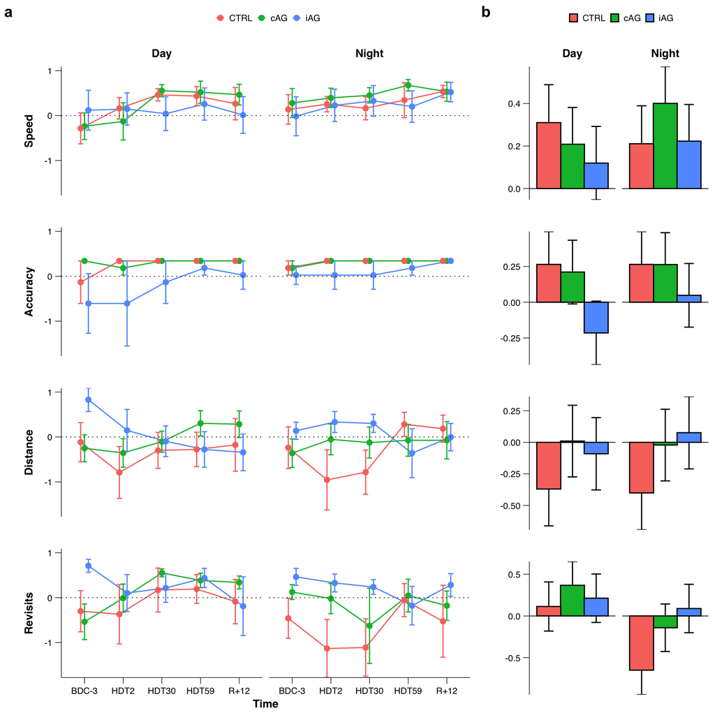

# 4 Four Mountains Task

## 4.1 Plot Time Course adjusted for Baseline

```r
# Plot arithmetic means

# Compute desc
desc <- func_desc(df_4mtn, group_3, time.f, variable)


# Plot desc
# New facet label names for variable
new_labels <- c("Speed","Accuracy","Efficiency")
names(new_labels) <- c("rt_z","acc_z","eff_z")

# Define labels for func_plot_line_facet
labeller_def <- labeller(variable = new_labels,
                                   cond.f = new_labels2)

facet_grid_def <- facet_grid(~ variable,
                             switch = "y",
                             labeller = labeller_def)

# Define aes for func_plot
tmpaes_plot <- aes(x = time.f, y = MEAN,
                   group = group_3,
                   fill = group_3,
                   color = group_3)

tmpaes_errorbar <- aes(x = time.f,
                    ymin = MEAN-SE,
                    ymax = MEAN+SE)
# Draw plot
pd <- position_dodge(0.3)
p.4mtn_desc <- func_plot_line_facet(desc %>%
                                      mutate(
                                        time.f = fct_relevel(time.f, "BDC-3", "HDT2", "HDT30", "HDT59", "R+12"),
                                        variable = fct_relevel(variable, "rt_z","acc_z","eff_z"),
                                        group_3 = fct_relevel(group_3, "CTRL", "cAG", "iAG")))

# Add zero line
p.4mtn_desc <- p.4mtn_desc + geom_hline(yintercept = 0, size = 0.3, linetype = "dotted")
```

## 4.2 Mixed Model Time in Bed Rest x Group Interaction

```r
# Add baseline as cov
bdc <- "BDC-3"
df_tmp <-  func_bdc_cov(df_4mtn)

# Select dep vars
dvList <- c("rt_z","acc_z","eff_z")

# Define model
model_mm <- paste0(" + sex"," + age", " + time.f",  " * group_3", " + (1|id)" )

# Run mixed models
tbl_mm_fac_aov <- sapply(func_mm_fac_with_bdc_adj_help(dvList), anova, simplify = FALSE, USE.NAMES = TRUE)

# ANOVA table
tbl_mm_fac_aov_df <- func_tbl_aov(dvList)

# Helper functions for parameter definition in mixed model tables, takes 'dvList'
Parameter_func <- function(dvList){
  rep(c(
  "Baseline",
  "Sex",
  "Age",
  "Time",
  "Group",
  "Time x Group"),
                 length(dvList))
}

# Add variables
Parameter <- Parameter_func(dvList)
blanks <- rep("", length(Parameter) / length(dvList) - 1)
Variable <- c("Speed", blanks,"Accuracy", blanks, "Precision", blanks)
tbl_mm_fac_aov_df_4mtn <- cbind(Variable, Parameter, tbl_mm_fac_aov_df[c(4:7)])
```

#### 4.2.0.1 Table 14. Mixed Model Summary for Four Mountains Task.

| Variable | Parameter | df1 | df2 | F | P |
| --- | --- | --- | --- | --- | --- |
| Speed | Baseline | 1 | 18 | 0.18 | 0.674 |
|  | Sex | 1 | 18 | 2.48 | 0.133 |
|  | Age | 1 | 18 | 2.58 | 0.126 |
|  | Time | 3 | 63 | 1.25 | 0.3 |
|  | Group | 2 | 18 | 2.05 | 0.157 |
|  | Time x Group | 6 | 63 | 0.4 | 0.878 |
| Accuracy | Baseline | 1 | 18 | 4.71 | 0.044 |
|  | Sex | 1 | 18 | 2 | 0.174 |
|  | Age | 1 | 18 | 1.35 | 0.26 |
|  | Time | 3 | 63 | 6.77 | 0 |

[output cut: 8 more lines]

## 4.3 Contrasts for Comparing Groups at Each Time Point

```r
# Contrasts
# Define model for contrasts
model_emmeans <- ~ time.f * group_3

# Define contrasts
contrast_type <- "pairwise"
factors <- c("time.f")

# Run contrasts
tbl_contr_emm_fac_df <- func_tbl_contr_emm_fac_with_bdc_adj(dvList)

# Create vars to make nice table
tmp_n_dvs <- length(levels(tbl_contr_emm_fac_df$Contrast)) *
  length(levels(tbl_contr_emm_fac_df$time.f))  -1
tmp_n_cond <- length(levels(tbl_contr_emm_fac_df$Contrast)) *
  length(levels(tbl_contr_emm_fac_df$time.f)) - 1
tmp_n_time <- length(levels(tbl_contr_emm_fac_df$Contrast)) - 1

Variable <- c("rt_z","acc_z","eff_z")

tbl_contr_emm_fac_df$Variable <- c("Speed", rep("", tmp_n_dvs),
                                   "Accuracy", rep("", tmp_n_dvs),
                                   "Efficiency", rep("", tmp_n_dvs))

tbl_contr_emm_fac_df$Time <- rep ( c("HDT2", rep("", tmp_n_time),
                                     "HDT30", rep("", tmp_n_time),
                                     "HDT59", rep("", tmp_n_time),
                                     "R+12", rep("", tmp_n_time)),
                                   length(dvList) )

#table_contrasts_emm_fac_by_time_df$Contrast <- rep(c("cAG vs. CTRL","iAG vs. CTRL", "cAG vs. iAG"), length(dvList))

# Table for contrasts
tbl_contr_emm_fac_df_4mtn <- tbl_contr_emm_fac_df[c(8:9, 2, 7, 3:6)]
```

#### 4.3.0.1 Table 15. Mixed Model Group Contrasts for Four Mountains Task.

| Variable | Time | Contrast | Mean (95%CI) | time.f | df | t | P (unadjusted) |
| --- | --- | --- | --- | --- | --- | --- | --- |
| Speed | HDT2 | cAG - CTRL | -0.98 (-2.06, 0.09) | HDT2 | 30.2 | -1.87 | 0.072 |
|  |  | cAG - iAG | -0.59 (-1.52, 0.35) | HDT2 | 35.7 | -1.27 | 0.214 |
|  |  | CTRL - iAG | 0.4 (-0.56, 1.35) | HDT2 | 34.8 | 0.85 | 0.403 |
|  | HDT30 | cAG - CTRL | -1.03 (-2.11, 0.04) | HDT30 | 30.2 | -1.96 | 0.059 |
|  |  | cAG - iAG | -0.44 (-1.38, 0.5) | HDT30 | 35.7 | -0.95 | 0.347 |
|  |  | CTRL - iAG | 0.59 (-0.36, 1.55) | HDT30 | 34.8 | 1.26 | 0.217 |
|  | HDT59 | cAG - CTRL | -0.59 (-1.67, 0.48) | HDT59 | 30.2 | -1.13 | 0.268 |
|  |  | cAG - iAG | -0.52 (-1.46, 0.42) | HDT59 | 35.7 | -1.13 | 0.268 |
|  |  | CTRL - iAG | 0.07 (-0.88, 1.03) | HDT59 | 34.8 | 0.16 | 0.877 |
|  | R+12 | cAG - CTRL | -1.08 (-2.16, -0.01) | R+12 | 30.2 | -2.06 | 0.049 |

[output cut: 26 more lines]

## 4.4 Plot Estimated Marignal Means To Show Time Course for Each Group

```r
# Define model for emmeans
model_emmeans <- ~ time.f * group_3

# Run emmeans
emm_fac <- func_emm_fac_with_bdc_adj(dvList)

# Plot emmeans
# New facet label names for variable
new_labels <- c("Speed","Accuracy","Efficiency")
names(new_labels) <- c("rt_z","acc_z","eff_z")

# Define aes for func_plot
tmpaes_plot <- aes(x = time.f, y = emmean,
                   group = group_3,
                   fill = group_3,
                   color = group_3)

tmpaes_errorbar <- aes(x = time.f,
                    ymin = emmean-SE,
                    ymax = emmean+SE)

# Define labels for func_plot_line_facet
labeller_def <- labeller(.id = new_labels)

facet_grid_def <- facet_grid(~ .id,
                             switch = "y",
                             labeller = labeller_def)

# Draw plot
pd <- position_dodge(0.3)
p.4mtn_emmeans <- func_plot_line_facet(emm_fac %>%
                                         mutate(
                                           time.f = fct_relevel(time.f, "BDC-3", "HDT2", "HDT30", "HDT59", "R+12"),
                                           .id = fct_relevel(.id, "rt_z","acc_z","eff_z"),
                                           group_3 = fct_relevel(group_3, "CTRL", "cAG", "iAG")))
# Add zero line
p.4mtn_emmeans <- p.4mtn_emmeans + geom_hline(yintercept = 0, size = 0.3, linetype = "dotted")

# Adjust legend size
p.4mtn_emmeans <- p.4mtn_emmeans + theme(legend.key.size = unit(0.3, "cm"))
```

## 4.5 Mixed Model for Main Effect of Bed Rest (excluding BDC)

```r
# Drop recovery
df_tmp <- subset(df_tmp, time.f !="R+12") # Drop baseline
df_tmp <- droplevels(df_tmp)

# Select dep vars
dvList <- c("rt_z","acc_z","eff_z")

# Define model
model_mm <- paste0(" + sex"," + age", " + group_3", " + (1|id)" )

# Run mixed models
tbl_mm_fac_aov <- sapply(func_mm_fac_with_bdc_adj_help(dvList), anova, simplify = FALSE, USE.NAMES = TRUE)

# ANOVA table
tbl_mm_fac_aov_df <- func_tbl_aov(dvList)

# Helper functions for parameter definition in mixed model tables, takes 'dvList'
Parameter_func <- function(dvList){
  rep(c(
  "Baseline",
  "Sex",
  "Age",
  "Group"),
                 length(dvList))
}

# Add variables
Parameter <- Parameter_func(dvList)
blanks <- rep("", length(Parameter) / length(dvList) - 1)
Variable <- c("Speed", blanks,"Accuracy", blanks, "Efficiency", blanks)
tbl_mm_fac_aov_df_4mtn_main <- cbind(Variable, Parameter, tbl_mm_fac_aov_df[c(4:7)])
```

#### 4.5.0.1 Table 16. Mixed Model Summary testing the Main Effect of Group for Four Mountains Task.

| Variable | Parameter | df1 | df2 | F | P |
| --- | --- | --- | --- | --- | --- |
| Speed | Baseline | 1 | 18 | 0 | 0.963 |
|  | Sex | 1 | 18 | 1.15 | 0.298 |
|  | Age | 1 | 18 | 1.24 | 0.28 |
|  | Group | 2 | 18 | 1.17 | 0.333 |
| Accuracy | Baseline | 1 | 18 | 4.88 | 0.04 |
|  | Sex | 1 | 18 | 0.88 | 0.361 |
|  | Age | 1 | 18 | 0.93 | 0.348 |
|  | Group | 2 | 18 | 1.42 | 0.268 |
| Efficiency | Baseline | 1 | 18 | 1.22 | 0.283 |
|  | Sex | 1 | 18 | 0.02 | 0.89 |

[output cut: 2 more lines]

## 4.6 Contrasts for Group Comparisons

```r
# Define model for emmeans
model_emmeans <- ~ group_3

# Run emmeans
emm_fac <- func_emm_fac_with_bdc_adj(dvList)

# Contrasts
# Define model for contrasts
model_emmeans <- ~ group_3

# Define contrasts
contrast_type <- "trt.vs.ctrl"
factors <- c()

# Run contrasts
tbl_contr_emm_fac_df <- func_tbl_contr_emm_fac_with_bdc_adj(dvList)

# Create vars to make nice table

tbl_contr_emm_fac_df$Variable <- c("Speed", rep("", 1),
                                   "Accuracy", rep("", 1),
                                   "Efficiency", rep("", 1))

#table_contrasts_emm_fac_by_time_df$Contrast <- rep(c("cAG vs. CTRL","iAG vs. CTRL", "cAG vs. iAG"), length(dvList))

# Table for contrasts
tbl_contr_emm_fac_4mtn_main <- tbl_contr_emm_fac_df[c(7, 2, 6, 3:5)]
```

#### 4.6.0.1 Table 17. Mixed Model Contrasts Comparing Groups for Four Mountains Task.

| Variable | Contrast | Mean (95%CI) | df | t | P (unadjusted) |
| --- | --- | --- | --- | --- | --- |
| Speed | CTRL - cAG | 0.72 (-0.29, 1.72) | 18 | 1.5 | 0.151 |
|  | iAG - cAG | 0.44 (-0.4, 1.28) | 18 | 1.11 | 0.281 |
| Accuracy | CTRL - cAG | -0.11 (-0.81, 0.6) | 18 | -0.32 | 0.751 |
|  | iAG - cAG | 0.44 (-0.3, 1.17) | 18 | 1.25 | 0.227 |
| Efficiency | CTRL - cAG | 0.15 (-0.48, 0.79) | 18 | 0.51 | 0.619 |
|  | iAG - cAG | 0.33 (-0.26, 0.93) | 18 | 1.18 | 0.253 |

## 4.7 Plot Estimated Marignal Means for Group Comparisons

```r
# New facet label names for variable
new_labels <- c("Speed","Accuracy","Efficiency")
names(new_labels) <- c("rt_z","acc_z","eff_z")

# Define aes for func_plot
tmpaes_plot <- aes(x = group_3, y = emmean,
                   group = group_3,
                   fill = group_3,
                   color = group_3)

tmpaes_errorbar <- aes(x = group_3,
                    ymin = emmean-SE,
                    ymax = emmean+SE)

tmpaes_geombar <- aes(x = group_3,
                    y = emmean,
                    fill=group_3)

# Define labels for func_plot_line_facet
labeller_def <- labeller(.id = new_labels)

facet_grid_def <- facet_grid(~ .id,
                             switch = "y",
                             labeller = labeller_def)
# Draw plot
pd <- position_dodge(1.5)
p.4mtn_emmeans_main <- func_plot_bar_facet(emm_fac %>%
                                             mutate(
                                               .id = fct_relevel(.id, "rt_z","acc_z","eff_z"),
                                               group_3 = fct_relevel(group_3, "CTRL", "cAG", "iAG")))

# Adjust legend size
p.4mtn_emmeans_main <- p.4mtn_emmeans_main + theme(legend.key.size = unit(0.3, "cm"))
```

## 4.8 Plot Combined plot

```r
# Combine plot
p.4mtn_comb <- plot_grid(p.4mtn_desc, p.4mtn_emmeans_main + rremove("x.text") + theme( strip.text.y = element_blank() ),
          labels = c("a", "b"),
          ncol = 2, nrow = 1,
          rel_widths = c(2.2, 0.8))

# Adjust legend size
p.4mtn_comb <- p.4mtn_comb + theme(legend.key.size = unit(0.3, "cm"))

# Save plot as pdf
pdf("./Figures/Spatial Cognition 1/p.4mtn_comb.pdf",
    width = 30/2.54,
    height = 20/2.54,
    useDingbats = FALSE) #in cm
print(p.4mtn_comb)
dev.off()
```

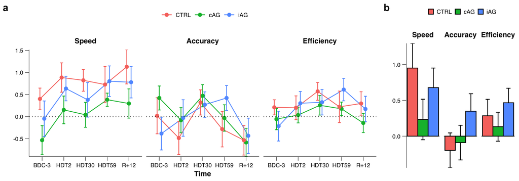